# Make a Map of Yosemite

`tmap` is a package for making thematic maps. In this Notebook, we’ll use `tmap` to make a map that includes the Yosemite:

- park boundary
- roads
- cell towers
- campgrounds

We’ll make two versions of the map - a traditional static map and an interactive map.

## Import all the layers

First, import the park boundary, cell towers, and roads. At the same time, we’ll (re)project everything into UTM 11N WGS 84.

```r
library(sf)
library(dplyr)

epsg_utm11n_wgs84 <- 32611

## Park boundary
yose_bnd_utm <- st_read(dsn="./data", layer="yose_boundary") |>
  st_transform(epsg_utm11n_wgs84)
## Roads
yose_roads_utm <- st_read("./data/yose_roads.gdb", "Yosemite_Roads") |>
  st_transform(epsg_utm11n_wgs84)
## Cell towers
gdb_fn <- "./data/yose_communications.gdb"; file.exists(gdb_fn)  ## two commands separated by ;
```

```
[1] TRUE
```

```r
yose_celltwrs_utm <- st_read(gdb_fn, "Cell_Towers") |>
  st_transform(epsg_utm11n_wgs84)
## Campsites
yose_campgrounds_utm <- st_read(dsn="./data", layer="yose_poi") |>
  st_transform(epsg_utm11n_wgs84) |>
  filter(POITYPE == "Campground")
```

## CHALLENGE: How many cell towers & campgrounds

How many cell towers are there? How many campgrounds are there? [Answer](https://bit.ly/3kyFMOT)

```r
# Your answer here
```

## Map the Park Boundary

Let’s start with a simple map of just the park boundary:

```r
library(tmap)
tmap_mode("plot")
```

```
tmap mode set to plotting
```

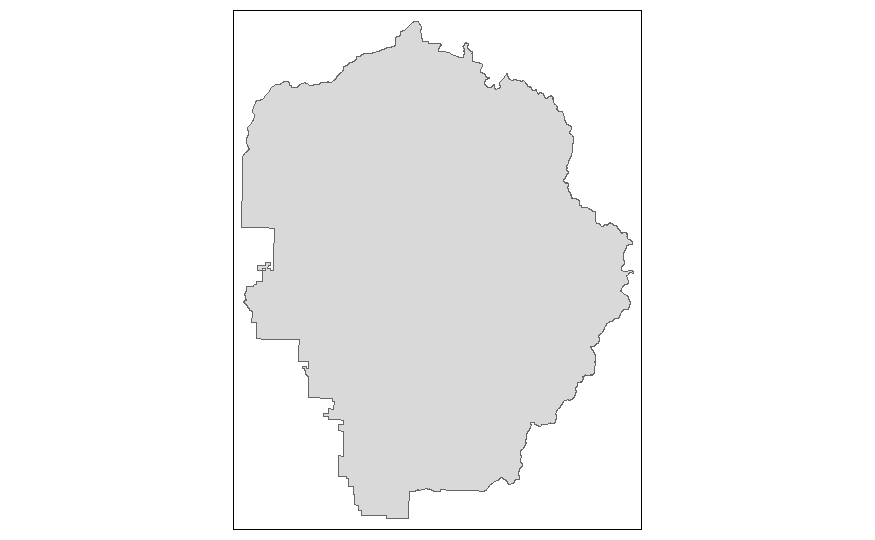

```r
tm_shape(yose_bnd_utm) + tm_polygons()
```

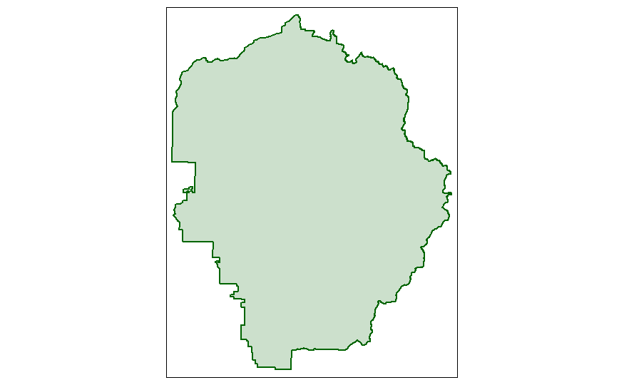

```r
tm_shape(yose_bnd_utm) +
  tm_polygons(col = "darkgreen", alpha = 0.2, border.col = "darkgreen", lwd = 2)
```

Next, we’ll add a title by adding `tm_layout()` to our tmap object:

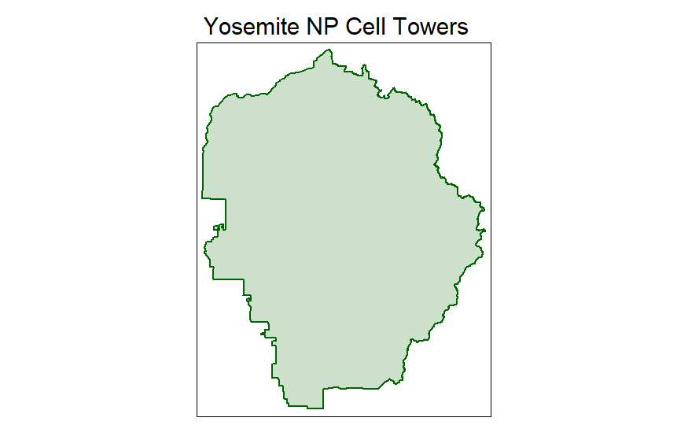

```r
tm_shape(yose_bnd_utm) +
  tm_polygons(col = "darkgreen", alpha = 0.2, border.col = "darkgreen", lwd = 2) +
tm_layout(main.title = "Yosemite NP Cell Towers")
```

## CHALLENGE: Add a scale bar

Add a scale bar to the map. Hint: add `tm_scale_bar()` to the map. [Answer](https://bit.ly/3hWmDVv)

```r
# Your answer here
```

## Add the Roads and the Cell Towers

Next we’ll add the roads. This requires tacking on another `tm_shape()`, followed by a function that draws lines.

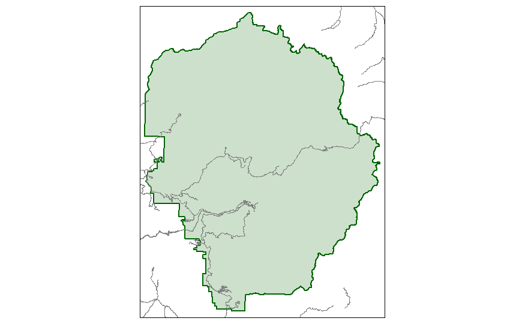

```r
tm_shape(yose_bnd_utm) +
  tm_polygons(col = "darkgreen", alpha = 0.2, border.col = "darkgreen", lwd = 2) +
tm_shape(yose_roads_utm) +
  tm_lines(col = "gray50")
```

In a similar fashion, we’ll add the cell towers as little blue dots:

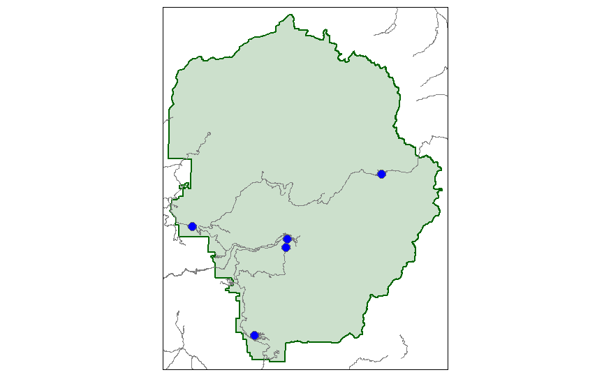

```r
tm_shape(yose_bnd_utm) +
  tm_polygons(col = "darkgreen", alpha = 0.2, border.col = "darkgreen", lwd = 2) +
tm_shape(yose_roads_utm) +
  tm_lines(col = "gray50") +
tm_shape(yose_celltwrs_utm) +
  tm_symbols(col = "blue", size = 0.5)
```

## CHALLENGE: Add the campgrounds

Add the campgrounds to the map as little red dots. Hint: you can render point layers with `tm_symbols()` or `tm_dots()`. [Answer](https://bit.ly/3hQjvdD)

```r
# Your answer here
```

## Make an interactive map

**Note**: interactive maps created by tmap can cause problems when you save a R Notebook to HTML. It is recommended that you run the following code in an R script rather than a Notebook.

We can switch to ‘interactive map mode’ by running `tmap_mode()`:

```
## tmap_mode("view")

## tmap_mode("plot")  # go back to plot mode
```

Now that we’re in ‘view’ mode, tmap objects be rendered as little interactive maps. We can ‘redraw’ the last tmap object using `tmap_last()`:

```
tmap_last()
```

Switch-out the basemap:

```
tm_shape(yose_bnd_utm |> st_geometry()) +
  tm_polygons(col = "darkgreen", alpha = 0.2, border.col = "darkgreen", lwd = 2) +
tm_shape(yose_roads_utm |> st_geometry()) +
  tm_lines(col = "gray50") +
tm_shape(yose_celltwrs_utm |> st_geometry()) +
  tm_symbols(col = "blue", size = 0.5) +
tm_shape(yose_campgrounds_utm |> st_geometry()) +
  tm_symbols(col = "red", size = 0.5) +
  tm_basemap("Esri.WorldTopoMap")
```

## Configure Pop-ups

Lastly we’ll disable interactivity (i.e., hover-over text and popup windows) on all layers except for the campgrounds:

```
tm_shape(yose_bnd_utm |> st_geometry()) +
  tm_polygons(col = "darkgreen", alpha = 0.2, border.col = "darkgreen", lwd = 2, interactive = FALSE) +
tm_shape(yose_roads_utm |> st_geometry()) +
  tm_lines(col = "gray50", interactive = FALSE) +
tm_shape(yose_celltwrs_utm |> st_geometry()) +
  tm_symbols(col = "blue", size = 0.5, interactive = FALSE) +
tm_shape(yose_campgrounds_utm |> select(POINAME)) +
  tm_symbols(col = "red", size = 0.5, id = "POINAME") +
  tm_basemap("Esri.WorldTopoMap")
```

Tip: for more control over pop-ups, use leaflet.

## End

Congratulations, you have completed the Notebook!

To view your Notebook at HTML, save it (again), then click the ‘Preview’ button in the RStudio toolbar.